# 03-Stumps, trees and forests

**Ecole Centrale Nantes**

**Diana Mateus**

PARTICIPANTS: HAD Ikrame - ASSERMOUH Meryam

```python
%matplotlib inline
import numpy as np
import matplotlib.pyplot as plt
from scipy import stats
```

## 1. Decision stumps

A decision stump is a machine learning model consisting of a one-level decision tree. That is, it is a decision tree with one internal node (the root) which is immediately connected to the terminal nodes (its leaves). A decision stump makes a prediction based on the value of just a single input feature. Sometimes they are also called 1-rules [Wikipedia]

*a)* Run the provided code to generate and plot a toy dataset consisting of 2D points and 4 classes

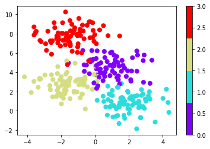

```python
#a) Load and plot dataset, split in train and test sets
from sklearn.datasets import make_blobs
from sklearn.model_selection import train_test_split

n_classes = 4
X, y = make_blobs(n_samples=300, centers=n_classes,
                  random_state=0, cluster_std=1.0)
plt.scatter(X[:, 0], X[:, 1], c=y, s=50, cmap=plt.cm.get_cmap('rainbow', 4));
plt.colorbar();

Xtrain, Xtest, ytrain, ytest = train_test_split(X, y, random_state=0)
```

**b)** Observe the functions **stump** and **split**.

**stump** is a function that generates the parameters of a random axis-aligned split according to the number of features of a given dataset. The function receives the data matrix Xtrain and returns

```
- the index of one randomly chosen feature (one dimension)
- as well as a randomly chosen threshold within the min and max values of the chosen feature.
```

**split** receives as input:

```
- A dataset of points
- the parameters generated by the stump function above.
```

The function then partitions the *dataset* in two subsets according to the threshold of the chosen dimension. The output are two arrays, each containing the *indices* of the points belonging to one or the other subset.

**c)** Run the split function **several times**, and display the resulting subsets as 2D scatter plots with circles of different colors for each class. Use the provided plotting functions.

```
Stump parameters 0 -3.593553014246913
Sizes: original set: 225  left subset: (5,)  right subset: (220,)
```

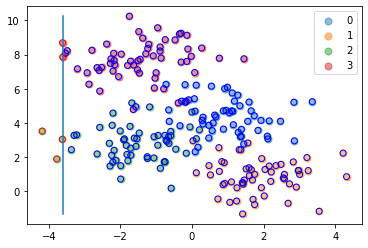

```python
from random import randint, uniform

# b) Stumps and Split

def stump(X):
    f = randint(0, X.shape[1]-1) #randomly select a feature/dimension randint()
    t = uniform(np.min(X[:,f]),np.max(X[:,f])) #sample from an uniform() between the min and max values of the feature
    return f,t


def split(X, f, t):
    ind_l, = np.where(X[:,f]<=t)
    ind_r, = np.where(X[:,f]>t)
    return ind_l, ind_r

# c) Plotting a stump

def plot_stump (Xtrain,ytrain,feat,th,ind_l,ind_r):
    n_classes=np.max(ytrain)+1;
    #print(n_classes)
    for c in range(n_classes):
        X0_c=Xtrain[np.where(ytrain==c), 0] #first coordinate of points belonging to class c
        X1_c=Xtrain[np.where(ytrain==c), 1] #second coordinate of points belonging to class c
        plt.scatter(X0_c,X1_c, s=50,alpha=0.5,cmap=plt.cm.get_cmap('rainbow', 4),label=str(c))

    #plt.axis('equal')

    #draw the points on the left and right child as circles around the original training dataset
    plt.scatter(Xtrain[ind_l, 0], Xtrain[ind_l, 1], c='none', edgecolor='r')
    plt.scatter(Xtrain[ind_r, 0], Xtrain[ind_r, 1], c='none', edgecolor='b')

    #draw threshold line
    if feat == 0:
        plt.plot([th,th],[np.min(Xtrain[:,1]),np.max(Xtrain[:,1])])
    elif feat == 1:
        plt.plot([np.min(Xtrain[:,0]),np.max(Xtrain[:,0])],[th,th])
    leg = plt.legend();


feat, th = stump(Xtrain)
print('Stump parameters', feat, th)
ind_l,ind_r = split(Xtrain, feat, th)
print('Sizes: original set:', len(ytrain),
      ' left subset:' ,  ind_l.shape,
      ' right subset:', ind_r.shape)


plot_stump(Xtrain,ytrain,feat,th,ind_l,ind_r)
```

**d)** Implement a function *class_distributions* that given a set of points reaching a node returns the posterior class distribution of the node (approximated as the normalized histogram with #points per class).

```
def class_distributions(ytrain,ind_left, ind_right):
```

Compute the class distributions of:

```
- of the original training set (before the split),
- of each of the 2 subsets resulting from after the split has been applied.
```

Plot the histograms of the children nodes

**e)** Create a function to compute the *information_gain* of a split. The function should receive the full training dataset (Xtrain and ytrain) and the indices of two subsets resulting from the current split.

```
def information_gain(ytrain,ind_left, ind_right):
```

`Hint:` when computing the Entropy, ignore the classes with zero probabilities, and carry on summation using the same equation.

```python
def class_distributions(ytrain):
    n_classes=np.max(ytrain)+1;
    print('Nombre de classes:',n_classes)
    plt.hist(ytrain, n_classes)
    plt.show()
```

```
Nombre de classes: 4
```

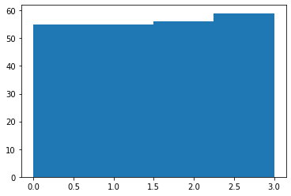

```python
#Class distribution of the original training set
class_distributions(ytrain)
```

```
Nombre de classes: 4
```

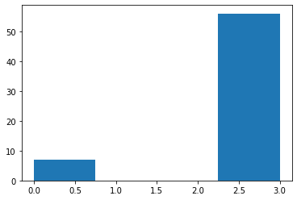

```
Right: [3, 3, 3, 3, 3, 3, 3, 3, 3, 3, 3, 3, 3, 3, 3, 3, 0, 3, 3, 3, 0, 3, 3, 3, 3, 3, 3, 3, 3, 3, 3, 3, 3, 0, 3, 3, 3, 0, 3, 3, 3, 3, 3, 3, 3, 3, 3, 3, 0, 3, 3, 3, 3, 0, 0, 3, 3, 3, 3, 3, 3, 3, 3]
Nombre de classes: 4
```

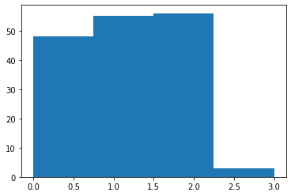

[output not shown]

```python
f,t=stump(Xtrain)
ind_l, ind_r=split(Xtrain, f, t)
right=[]
left=[]
for i in range(len(ind_r)):
    right.append(ytrain[ind_r[i]])
for i in range(len(ind_l)):
    left.append(ytrain[ind_l[i]])
#Class distribution of the training after the split (right)
class_distributions(right)
print('Right:',right)
#Class distribution of the training after the split (left)
class_distributions(left)
print('Left:',left)
```

```python
import math

def entropie(ytrain):
    n_classes=np.max(ytrain)+1;
    Hq=0
    for k in range(n_classes):
        if np.count_nonzero(ytrain == k)!= 0:
            Hq=Hq-np.count_nonzero(ytrain == k)/len(ytrain)*math.log2(np.count_nonzero(ytrain == k)/len(ytrain))
    return Hq

def information_gain(ytrain,ind_left, ind_right):
    right=[]
    left=[]
    for i in range(len(ind_right)):
        right.append(ytrain[ind_right[i]])
    for i in range(len(ind_left)):
        left.append(ytrain[ind_left[i]])
    right=np.array(right)
    left=np.array(left)
    Hq=entropie(ytrain)
    H_right=entropie(right)
    H_left=entropie(left)
    IFG=Hq-len(left)/len(ytrain)*H_left-len(right)/len(ytrain)*H_right
    return IFG
```

```python
f,t=stump(Xtrain)
ind_l, ind_r=split(Xtrain, f, t)
IFG=information_gain(ytrain,ind_l, ind_r)
print('Information Gain:',IFG)
```

```
Information Gain: 0.5356497059059389
```

**f)** Create a function *train* to perfom a *randomized node optimization*. The function receives as parameters the full training dataset (Xtrain and ytrain) as well as the number of random stumps to try. The function will

- generate the desired number of stumps,
- split the dataset according to each stump,
- evaluate the *information gain* for each split
- choose and then return the parameters of the best stump.

```
def train_stumps(Xtrain, ytrain, trials):
```

Print the progress of the information gain during the training process

**g)** Make predictions with the trained model and display the restuls

```python
def train_stumps(Xtrain, ytrain, trials):
    parameters=[]
    IFGs=[]
    for i in range(trials):
        (f,t)= stump(Xtrain)
        parameters.append((f,t))
        ind_l,ind_r=split(Xtrain, f, t)
        IFG=information_gain(ytrain,ind_l, ind_r)
        IFGs.append(IFG)
    max_value = None
    max_idx = None
    for idx, num in enumerate(IFGs):
        if (max_value is None or num > max_value):
            max_value = num
            max_idx = idx
    print('Maximum value:', max_value, "At index: ", max_idx)
    best_parameters=parameters[max_idx]
    print('Best parameters:',best_parameters)
    return best_parameters,max_value
```

```python
train_stumps(Xtrain, ytrain,1000)
```

```
Maximum value: 0.6920053565114201 At index:  408
Best parameters: (0, 0.003004007716892687)
```

```
((0, 0.003004007716892687), 0.6920053565114201)
```

```
Maximum value: 0.6958130966007405 At index:  54
Best parameters: (1, 3.8648653279080665)
```

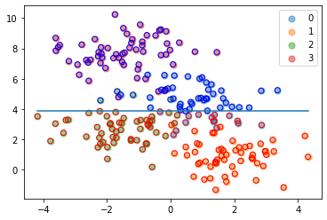

```python
best_parameters,best_InfoGain = train_stumps(Xtrain, ytrain, 1000)
feat=best_parameters[0]
threshold=best_parameters[1]
ind_left, ind_right = split(Xtrain,int(feat),threshold)
plot_stump (Xtrain,ytrain,feat, threshold,ind_left, ind_right)
```

## 3. Comparing classifiers on the Caltech 101 dataset

Compare the performances of an SVM, a Decision Tree and Random Forest classifiers on the **Caltech 101** dataset for a binary classification task (e.g. dragonfly vs crayfish)

**a)** Load and split the dataset into train and test with 75% and 25% respective proportions

**b)** Train three classification models on the train dataset

- an SVM
- a single decision tree `sklearn.tree.DecisionTree`
- a Random Forest `sklearn.ensemble.RandomForestClassifier`

Print the accuracy on the train and test sets for each model. `from sklearn import metrics`

**c)** Plot the roc curves for each model, and compute the areas under the curve

**d)** Do a gridsearch with a 5-fold crossvalidation varying the hyperparameters of each model (e.g., for the SVM the `kernel`, the `gamma` and `c`, and for the tree-based models `max_depth`, `max_features`, `min_samples_leaf`, and `n_estimators`).

`from sklearn.model_selection import GridSearchCV`

**Hint**

```
tuned_parameters = [{'max_depth': [1, 5, 10],
                     'max_features': [1, 15, 30, 45, 60],
                     'n_estimators': [1, 25, 50, 75, 100],
                     'min_samples_leaf': [3,5,10]}]
```

- What are the best parameters found to maximize the area under the curve in each case?

**e)** Discuss the results and curves.

```python
import os
import skimage
from skimage import io
import random
from skimage.color import rgb2gray
from skimage.transform import resize
from sklearn.svm import SVC
from sklearn.utils import shuffle

## VERIFY LOCATION AND STORE LABEL NAMES
IMDIR1 = '101Caltech/101_ObjectCategories/101_ObjectCategories/crayfish'
IMDIR2= '101Caltech/101_ObjectCategories/101_ObjectCategories/dragonfly'

K = 2
N = 40
imWidth = 100 #resize images
imHeight = 100

#selection of label indices
X = np.zeros([K*N,imHeight*imWidth]) #data matrix, one image per row
Y = -np.ones([K*N,1]) #label indices

paths = [IMDIR1, IMDIR2]
globalCount = 0
for i in range(K):

    #folders are named after the class label
    filedir = os.path.join(paths[i])
    print(filedir)

    #save the name of the class
    classCount = 0
    for filename in os.listdir(filedir):
        f = os.path.join(filedir, filename)
        if f.endswith(('.jpg')) and (classCount < N):
            #image = skimage.io.imread(f, as_grey=True) #Try this line instead of the one below if there is an error
            image = skimage.io.imread(f, as_gray=True)
            image = skimage.transform.resize(image, [imHeight,imWidth],mode='constant')#,anti_aliasing=True)
            X[globalCount,:] = image.flatten()
            Y[globalCount,:] = i
            globalCount += 1
            classCount += 1

#Remove the unused entries of X and Y
print("Total number of samples",globalCount)
X = X[:globalCount,:]
Y = Y[:globalCount,:]

#Check the stored classes
print("Size of data matrix", X.shape)
print("class labels", Y.T)
print('shape of Y:', Y.T.shape)
```

```
101Caltech/101_ObjectCategories/101_ObjectCategories/crayfish
101Caltech/101_ObjectCategories/101_ObjectCategories/dragonfly
Total number of samples 80
Size of data matrix (80, 10000)
class labels [[0. 0. 0. 0. 0. 0. 0. 0. 0. 0. 0. 0. 0. 0. 0. 0. 0. 0. 0. 0. 0. 0. 0. 0.
  0. 0. 0. 0. 0. 0. 0. 0. 0. 0. 0. 0. 0. 0. 0. 0. 1. 1. 1. 1. 1. 1. 1. 1.
  1. 1. 1. 1. 1. 1. 1. 1. 1. 1. 1. 1. 1. 1. 1. 1. 1. 1. 1. 1. 1. 1. 1. 1.
  1. 1. 1. 1. 1. 1. 1. 1.]]
shape of Y: (1, 80)
```

```python
#Load and split the dataset into train and test with 75% and 25% respective proportions

Ntrain = np.rint(.75*Y.shape[0]).astype(int)
Ntest = Y.shape[0]-Ntrain
print('Training with', Ntrain , 'training samples and ', Ntest, 'testing samples.')

# Randomize the order of X and Y
X, Y = shuffle(X, Y, random_state=0)


# Split the data and labels into training/testing sets
X_train = X[0:Ntrain,:]
Y_train = Y[0:Ntrain,:]

X_test = X[Ntrain:,:]
Y_test = Y[Ntrain:,:]

print("size of train dataset",X_train.shape)
print("size of test dataset",X_test.shape)
print("train target vector",Y_train.T)
print("test target vector",Y_test.T)
```

```
Training with 60 training samples and  20 testing samples.
size of train dataset (60, 10000)
size of test dataset (20, 10000)
train target vector [[1. 0. 0. 1. 1. 1. 1. 1. 1. 1. 1. 1. 0. 1. 1. 0. 0. 0. 0. 0. 1. 0. 1. 1.
  1. 0. 1. 1. 0. 1. 1. 0. 0. 1. 0. 0. 1. 0. 0. 0. 1. 1. 0. 0. 1. 0. 1. 0.
  0. 1. 0. 0. 0. 0. 1. 0. 0. 1. 0. 1.]]
test target vector [[0. 1. 0. 0. 0. 0. 1. 0. 1. 1. 0. 1. 0. 0. 0. 1. 1. 1. 1. 1.]]
```

```
True classes [[0. 1. 0. 0. 0. 0. 1. 0. 1. 1. 0. 1. 0. 0. 0. 1. 1. 1. 1. 1.]]
Predictions of the SVM model  [0. 0. 0. 0. 1. 0. 0. 0. 0. 0. 0. 1. 1. 1. 0. 1. 0. 0. 1. 1.]
There were  9 errors
Accuracy of the SVM model:  0.55
Predictions of the single decision tree model  [1. 1. 0. 0. 0. 1. 1. 0. 1. 0. 0. 0. 0. 1. 1. 1. 0. 1. 0. 1.]
There were  8 errors
Accuracy of the single decision tree model:  0.6
```

```
Predictions of the random forest model  [0. 1. 0. 0. 1. 1. 0. 0. 1. 0. 0. 1. 1. 1. 0. 1. 0. 1. 1. 1.]
There were  7 errors
Accuracy of the random forest model:  0.65
```

```
<sklearn.metrics._plot.roc_curve.RocCurveDisplay at 0x1e6775804c0>
```

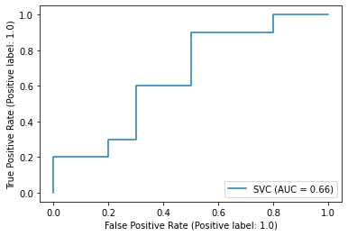

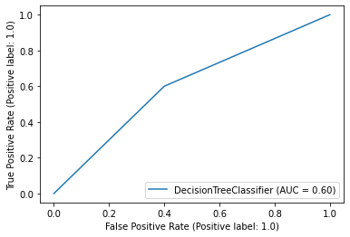

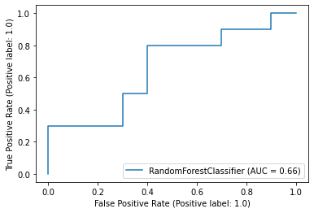

```python
from sklearn.tree import DecisionTreeClassifier
from sklearn.ensemble import RandomForestClassifier
from sklearn.metrics import accuracy_score
from sklearn.metrics import roc_curve

#SVM classification model
svc = SVC()
svc.fit(X_train,Y_train)
Y_pred_svm=svc.predict(X_test)

print("True classes",Y_test.T)
print("Predictions of the SVM model ",Y_pred_svm)
errors = np.sum((Y_test.ravel()!=Y_pred_svm))
print('There were ', errors, 'errors')
print('Accuracy of the SVM model: ',accuracy_score(Y_test,Y_pred_svm))
metrics.plot_roc_curve(svc, X_test, Y_test)

#single decision tree classificaton model
DecisionTree = DecisionTreeClassifier(max_depth=1,random_state=0)
DecisionTree.fit(X_train,Y_train)
Y_pred_dt=DecisionTree.predict(X_test)

print("Predictions of the single decision tree model ",Y_pred_dt)
errors = np.sum((Y_test.ravel()!=Y_pred_dt))
print('There were ', errors, 'errors')
print('Accuracy of the single decision tree model: ',accuracy_score(Y_test,Y_pred_dt))
metrics.plot_roc_curve(DecisionTree, X_test, Y_test)

#Random Forest classification model
RandomForest = RandomForestClassifier(max_depth=2, random_state=0)
RandomForest.fit(X_train,Y_train)
Y_pred_rf=RandomForest.predict(X_test)

print("Predictions of the random forest model ",Y_pred_rf)
errors = np.sum((Y_test.ravel()!=Y_pred_rf))
print('There were ', errors, 'errors')
print('Accuracy of the random forest model: ',accuracy_score(Y_test,Y_pred_rf))
metrics.plot_roc_curve(RandomForest, X_test, Y_test)
```

```python
from sklearn.model_selection import GridSearchCV

#best parameters for the SVM model

params_svm = {'C': [0.1,1, 10, 100], 'gamma': [1,0.1,0.01,0.001],'kernel': ['rbf', 'poly', 'sigmoid']}
gs_svm = GridSearchCV(SVC(),params_svm,refit=True,verbose=2)
gs_svm.fit(X_train,Y_train)
print('Best parameters for the SVM model: ',gs_svm.best_params_)
print('Best score of the SVM model: ',gs_svm.best_score_)
```

[output not shown]

[output not shown]

[output not shown]

[output not shown]

[output not shown]

[output not shown]

[output not shown]

[output not shown]

[output not shown]

[output not shown]

[output not shown]

[output not shown]

[output not shown]

[output not shown]

[output not shown]

[output not shown]

[output not shown]

[output not shown]

[output not shown]

[output not shown]

[output not shown]

[output not shown]

[output not shown]

[output not shown]

[output not shown]

[output not shown]

[output not shown]

[output not shown]

[output not shown]

[output not shown]

[output not shown]

[output not shown]

[output not shown]

[output not shown]

[output not shown]

[output not shown]

[output not shown]

[output not shown]

[output not shown]

[output not shown]

[output not shown]

[output not shown]

[output not shown]

[output not shown]

[output not shown]

[output not shown]

[output not shown]

[output not shown]

[output not shown]

[output not shown]

[output not shown]

[output not shown]

[output not shown]

[output not shown]

[output not shown]

[output not shown]

[output not shown]

[output not shown]

[output not shown]

[output not shown]

[output not shown]

[output not shown]

[output not shown]

[output not shown]

[output not shown]

[output not shown]

[output not shown]

[output not shown]

[output not shown]

[output not shown]

```
[CV] END .................C=100, gamma=0.001, kernel=sigmoid; total time=   0.0s
[CV] END .................C=100, gamma=0.001, kernel=sigmoid; total time=   0.0s
[CV] END .................C=100, gamma=0.001, kernel=sigmoid; total time=   0.0s
[CV] END .................C=100, gamma=0.001, kernel=sigmoid; total time=   0.0s
[CV] END .................C=100, gamma=0.001, kernel=sigmoid; total time=   0.0s
Best parameters for the SVM model:  {'C': 0.1, 'gamma': 0.001, 'kernel': 'poly'}
Best score of the SVM model:  0.7666666666666666
```

```python
#best parameters for the Decison Tree model

params_DecisonTree = {'max_depth': [1, 5, 10],
                       'max_features': [1, 15, 30, 45, 60],
                       'min_samples_leaf': [3,5,10]}
gs_DecisonTree = GridSearchCV(DecisionTreeClassifier(),params_DecisonTree,refit=True,verbose=2)
gs_DecisonTree.fit(X_train,Y_train)
print('Best parameters for the Decison Tree model: ',gs_DecisonTree.best_params_)
print('Best score of the Decison Tree model: ',gs_DecisonTree.best_score_)
```

[output not shown]

[output cut: 173 more lines]

```
[CV] END ..max_depth=10, max_features=60, min_samples_leaf=3; total time=   0.0s
[CV] END ..max_depth=10, max_features=60, min_samples_leaf=3; total time=   0.0s
[CV] END ..max_depth=10, max_features=60, min_samples_leaf=3; total time=   0.0s
[CV] END ..max_depth=10, max_features=60, min_samples_leaf=5; total time=   0.0s
[CV] END ..max_depth=10, max_features=60, min_samples_leaf=5; total time=   0.0s
[CV] END ..max_depth=10, max_features=60, min_samples_leaf=5; total time=   0.0s
[CV] END ..max_depth=10, max_features=60, min_samples_leaf=5; total time=   0.0s
[CV] END ..max_depth=10, max_features=60, min_samples_leaf=5; total time=   0.0s
[CV] END .max_depth=10, max_features=60, min_samples_leaf=10; total time=   0.0s
[CV] END .max_depth=10, max_features=60, min_samples_leaf=10; total time=   0.0s
[CV] END .max_depth=10, max_features=60, min_samples_leaf=10; total time=   0.0s
[CV] END .max_depth=10, max_features=60, min_samples_leaf=10; total time=   0.0s
[CV] END .max_depth=10, max_features=60, min_samples_leaf=10; total time=   0.0s
Best parameters for the Decison Tree model:  {'max_depth': 1, 'max_features': 15, 'min_samples_leaf': 3}
Best score of the Decison Tree model:  0.6833333333333333
```

```python
#best parameters for the Random Forest model

params_RandomForest = {'max_depth': [1, 5, 10],
                       'max_features': [1, 15, 30, 45, 60],
                       'n_estimators': [1, 25, 50, 75, 100],
                       'min_samples_leaf': [3,5,10]}
gs_RandomForest = GridSearchCV(RandomForestClassifier(),params_RandomForest,refit=True,verbose=2)
gs_RandomForest.fit(X_train,Y_train)
print('Best parameters for the Random Forest model: ',gs_RandomForest.best_params_)
print('Best score of the Random Forest model: ',gs_RandomForest.best_score_)
```

[output not shown]

[output not shown]

[output not shown]

[output not shown]

[output not shown]

[output not shown]

[output not shown]

[output not shown]

[output not shown]

[output not shown]

[output not shown]

[output not shown]

[output not shown]

[output not shown]

[output not shown]

[output not shown]

[output not shown]

[output not shown]

[output not shown]

[output not shown]

[output not shown]

[output not shown]

[output not shown]

[output not shown]

[output not shown]

[output not shown]

[output not shown]

[output not shown]

[output not shown]

[output not shown]

[output not shown]

[output not shown]

[output not shown]

[output not shown]

[output not shown]

[output not shown]

[output not shown]

[output not shown]

[output not shown]

[output not shown]

[output not shown]

[output not shown]

[output not shown]

[output not shown]

[output not shown]

[output not shown]

[output not shown]

[output not shown]

[output not shown]

[output not shown]

[output not shown]

[output not shown]

[output not shown]

[output not shown]

[output not shown]

[output not shown]

[output not shown]

[output not shown]

[output not shown]

[output not shown]

[output not shown]

[output not shown]

[output not shown]

[output not shown]

[output not shown]

[output not shown]

[output not shown]

[output not shown]

[output not shown]

[output not shown]

[output not shown]

[output not shown]

[output not shown]

[output not shown]

[output not shown]

[output not shown]

[output not shown]

[output not shown]

[output not shown]

[output not shown]

[output not shown]

[output not shown]

[output not shown]

[output not shown]

[output not shown]

[output not shown]

[output not shown]

[output not shown]

[output not shown]

[output not shown]

[output not shown]

[output not shown]

[output not shown]

[output not shown]

[output not shown]

[output not shown]

[output not shown]

[output not shown]

[output not shown]

[output not shown]

[output not shown]

[output not shown]

[output not shown]

[output not shown]

[output not shown]

[output not shown]

[output not shown]

[output not shown]

[output not shown]

[output not shown]

[output not shown]

[output not shown]

[output not shown]

[output not shown]

[output not shown]

[output not shown]

```
[CV] END max_depth=1, max_features=30, min_samples_leaf=3, n_estimators=50; total time=   0.3s
```

```
[CV] END max_depth=1, max_features=30, min_samples_leaf=3, n_estimators=50; total time=   0.2s
```

```
[CV] END max_depth=1, max_features=30, min_samples_leaf=3, n_estimators=75; total time=   0.5s
```

```
[CV] END max_depth=1, max_features=30, min_samples_leaf=3, n_estimators=75; total time=   0.4s
```

```
[CV] END max_depth=1, max_features=30, min_samples_leaf=3, n_estimators=75; total time=   0.4s
```

```
[CV] END max_depth=1, max_features=30, min_samples_leaf=3, n_estimators=75; total time=   0.4s
```

```
[CV] END max_depth=1, max_features=30, min_samples_leaf=3, n_estimators=75; total time=   0.4s
```

```
[CV] END max_depth=1, max_features=30, min_samples_leaf=3, n_estimators=100; total time=   0.7s
```

```
[CV] END max_depth=1, max_features=30, min_samples_leaf=3, n_estimators=100; total time=   0.6s
```

```
[CV] END max_depth=1, max_features=30, min_samples_leaf=3, n_estimators=100; total time=   0.5s
```

```
[CV] END max_depth=1, max_features=30, min_samples_leaf=3, n_estimators=100; total time=   0.7s
```

[output not shown]

```
[CV] END max_depth=1, max_features=30, min_samples_leaf=5, n_estimators=25; total time=   0.1s
[CV] END max_depth=1, max_features=30, min_samples_leaf=5, n_estimators=25; total time=   0.1s
```

```
[CV] END max_depth=1, max_features=30, min_samples_leaf=5, n_estimators=25; total time=   0.1s
```

```
[CV] END max_depth=1, max_features=30, min_samples_leaf=5, n_estimators=25; total time=   0.1s
[CV] END max_depth=1, max_features=30, min_samples_leaf=5, n_estimators=25; total time=   0.1s
```

```
[CV] END max_depth=1, max_features=30, min_samples_leaf=5, n_estimators=50; total time=   0.3s
```

```
[CV] END max_depth=1, max_features=30, min_samples_leaf=5, n_estimators=50; total time=   0.2s
```

```
[CV] END max_depth=1, max_features=30, min_samples_leaf=5, n_estimators=50; total time=   0.3s
```

```
[CV] END max_depth=1, max_features=30, min_samples_leaf=5, n_estimators=50; total time=   0.2s
```

```
[CV] END max_depth=1, max_features=30, min_samples_leaf=5, n_estimators=50; total time=   0.2s
```

```
[CV] END max_depth=1, max_features=30, min_samples_leaf=5, n_estimators=75; total time=   0.5s
```

```
[CV] END max_depth=1, max_features=30, min_samples_leaf=5, n_estimators=75; total time=   0.3s
```

```
[CV] END max_depth=1, max_features=30, min_samples_leaf=5, n_estimators=75; total time=   0.5s
```

```
[CV] END max_depth=1, max_features=30, min_samples_leaf=5, n_estimators=75; total time=   0.5s
```

```
[CV] END max_depth=1, max_features=30, min_samples_leaf=5, n_estimators=75; total time=   0.4s
```

```
[CV] END max_depth=1, max_features=30, min_samples_leaf=5, n_estimators=100; total time=   0.8s
```

```
[CV] END max_depth=1, max_features=30, min_samples_leaf=5, n_estimators=100; total time=   0.7s
```

```
[CV] END max_depth=1, max_features=30, min_samples_leaf=5, n_estimators=100; total time=   0.7s
```

```
[CV] END max_depth=1, max_features=30, min_samples_leaf=5, n_estimators=100; total time=   1.0s
```

[output not shown]

```
[CV] END max_depth=1, max_features=30, min_samples_leaf=10, n_estimators=25; total time=   0.1s
```

```
[CV] END max_depth=1, max_features=30, min_samples_leaf=10, n_estimators=25; total time=   0.1s
```

```
[CV] END max_depth=1, max_features=30, min_samples_leaf=10, n_estimators=25; total time=   0.1s
[CV] END max_depth=1, max_features=30, min_samples_leaf=10, n_estimators=25; total time=   0.1s
```

```
[CV] END max_depth=1, max_features=30, min_samples_leaf=10, n_estimators=25; total time=   0.1s
```

```
[CV] END max_depth=1, max_features=30, min_samples_leaf=10, n_estimators=50; total time=   0.3s
```

```
[CV] END max_depth=1, max_features=30, min_samples_leaf=10, n_estimators=50; total time=   0.3s
```

```
[CV] END max_depth=1, max_features=30, min_samples_leaf=10, n_estimators=50; total time=   0.6s
```

```
[CV] END max_depth=1, max_features=30, min_samples_leaf=10, n_estimators=50; total time=   0.5s
```

```
[CV] END max_depth=1, max_features=30, min_samples_leaf=10, n_estimators=50; total time=   0.7s
```

```
[CV] END max_depth=1, max_features=30, min_samples_leaf=10, n_estimators=75; total time=   0.8s
```

```
[CV] END max_depth=1, max_features=30, min_samples_leaf=10, n_estimators=75; total time=   0.7s
```

```
[CV] END max_depth=1, max_features=30, min_samples_leaf=10, n_estimators=75; total time=   0.6s
```

```
[CV] END max_depth=1, max_features=30, min_samples_leaf=10, n_estimators=75; total time=   0.5s
```

```
[CV] END max_depth=1, max_features=30, min_samples_leaf=10, n_estimators=75; total time=   0.5s
```

```
[CV] END max_depth=1, max_features=30, min_samples_leaf=10, n_estimators=100; total time=   0.6s
```

```
[CV] END max_depth=1, max_features=30, min_samples_leaf=10, n_estimators=100; total time=   0.6s
```

```
[CV] END max_depth=1, max_features=30, min_samples_leaf=10, n_estimators=100; total time=   0.5s
```

```
[CV] END max_depth=1, max_features=30, min_samples_leaf=10, n_estimators=100; total time=   0.4s
```

[output not shown]

```
[CV] END max_depth=1, max_features=45, min_samples_leaf=3, n_estimators=25; total time=   0.0s
[CV] END max_depth=1, max_features=45, min_samples_leaf=3, n_estimators=25; total time=   0.1s
```

```
[CV] END max_depth=1, max_features=45, min_samples_leaf=3, n_estimators=25; total time=   0.1s
[CV] END max_depth=1, max_features=45, min_samples_leaf=3, n_estimators=25; total time=   0.1s
```

```
[CV] END max_depth=1, max_features=45, min_samples_leaf=3, n_estimators=25; total time=   0.1s
```

```
[CV] END max_depth=1, max_features=45, min_samples_leaf=3, n_estimators=50; total time=   0.2s
```

```
[CV] END max_depth=1, max_features=45, min_samples_leaf=3, n_estimators=50; total time=   0.2s
```

```
[CV] END max_depth=1, max_features=45, min_samples_leaf=3, n_estimators=50; total time=   0.3s
```

```
[CV] END max_depth=1, max_features=45, min_samples_leaf=3, n_estimators=50; total time=   0.2s
```

```
[CV] END max_depth=1, max_features=45, min_samples_leaf=3, n_estimators=50; total time=   0.4s
```

```
[CV] END max_depth=1, max_features=45, min_samples_leaf=3, n_estimators=75; total time=   0.6s
```

```
[CV] END max_depth=1, max_features=45, min_samples_leaf=3, n_estimators=75; total time=   0.4s
```

```
[CV] END max_depth=1, max_features=45, min_samples_leaf=3, n_estimators=75; total time=   0.4s
```

```
[CV] END max_depth=1, max_features=45, min_samples_leaf=3, n_estimators=75; total time=   0.4s
```

```
[CV] END max_depth=1, max_features=45, min_samples_leaf=3, n_estimators=75; total time=   0.4s
```

```
[CV] END max_depth=1, max_features=45, min_samples_leaf=3, n_estimators=100; total time=   0.9s
```

```
[CV] END max_depth=1, max_features=45, min_samples_leaf=3, n_estimators=100; total time=   0.7s
```

```
[CV] END max_depth=1, max_features=45, min_samples_leaf=3, n_estimators=100; total time=   0.9s
```

```
[CV] END max_depth=1, max_features=45, min_samples_leaf=3, n_estimators=100; total time=   0.8s
```

[output not shown]

```
[CV] END max_depth=1, max_features=45, min_samples_leaf=5, n_estimators=25; total time=   0.1s
[CV] END max_depth=1, max_features=45, min_samples_leaf=5, n_estimators=25; total time=   0.1s
```

```
[CV] END max_depth=1, max_features=45, min_samples_leaf=5, n_estimators=25; total time=   0.0s
[CV] END max_depth=1, max_features=45, min_samples_leaf=5, n_estimators=25; total time=   0.1s
```

```
[CV] END max_depth=1, max_features=45, min_samples_leaf=5, n_estimators=25; total time=   0.1s
[CV] END max_depth=1, max_features=45, min_samples_leaf=5, n_estimators=50; total time=   0.2s
```

```
[CV] END max_depth=1, max_features=45, min_samples_leaf=5, n_estimators=50; total time=   0.4s
```

```
[CV] END max_depth=1, max_features=45, min_samples_leaf=5, n_estimators=50; total time=   0.4s
```

```
[CV] END max_depth=1, max_features=45, min_samples_leaf=5, n_estimators=50; total time=   0.4s
```

```
[CV] END max_depth=1, max_features=45, min_samples_leaf=5, n_estimators=50; total time=   0.4s
```

```
[CV] END max_depth=1, max_features=45, min_samples_leaf=5, n_estimators=75; total time=   0.6s
```

```
[CV] END max_depth=1, max_features=45, min_samples_leaf=5, n_estimators=75; total time=   0.6s
```

```
[CV] END max_depth=1, max_features=45, min_samples_leaf=5, n_estimators=75; total time=   0.5s
```

```
[CV] END max_depth=1, max_features=45, min_samples_leaf=5, n_estimators=75; total time=   0.6s
```

```
[CV] END max_depth=1, max_features=45, min_samples_leaf=5, n_estimators=75; total time=   0.5s
```

```
[CV] END max_depth=1, max_features=45, min_samples_leaf=5, n_estimators=100; total time=   0.7s
```

```
[CV] END max_depth=1, max_features=45, min_samples_leaf=5, n_estimators=100; total time=   0.5s
```

```
[CV] END max_depth=1, max_features=45, min_samples_leaf=5, n_estimators=100; total time=   0.6s
```

```
[CV] END max_depth=1, max_features=45, min_samples_leaf=5, n_estimators=100; total time=   0.6s
```

[output not shown]

```
[CV] END max_depth=1, max_features=45, min_samples_leaf=10, n_estimators=25; total time=   0.1s
```

```
[CV] END max_depth=1, max_features=45, min_samples_leaf=10, n_estimators=25; total time=   0.1s
[CV] END max_depth=1, max_features=45, min_samples_leaf=10, n_estimators=25; total time=   0.1s
```

```
[CV] END max_depth=1, max_features=45, min_samples_leaf=10, n_estimators=25; total time=   0.1s
```

```
[CV] END max_depth=1, max_features=45, min_samples_leaf=10, n_estimators=25; total time=   0.1s
```

```
[CV] END max_depth=1, max_features=45, min_samples_leaf=10, n_estimators=50; total time=   0.3s
```

```
[CV] END max_depth=1, max_features=45, min_samples_leaf=10, n_estimators=50; total time=   0.3s
```

```
[CV] END max_depth=1, max_features=45, min_samples_leaf=10, n_estimators=50; total time=   0.3s
```

```
[CV] END max_depth=1, max_features=45, min_samples_leaf=10, n_estimators=50; total time=   0.3s
```

```
[CV] END max_depth=1, max_features=45, min_samples_leaf=10, n_estimators=50; total time=   0.3s
```

```
[CV] END max_depth=1, max_features=45, min_samples_leaf=10, n_estimators=75; total time=   0.4s
```

```
[CV] END max_depth=1, max_features=45, min_samples_leaf=10, n_estimators=75; total time=   0.4s
```

```
[CV] END max_depth=1, max_features=45, min_samples_leaf=10, n_estimators=75; total time=   0.4s
```

```
[CV] END max_depth=1, max_features=45, min_samples_leaf=10, n_estimators=75; total time=   0.6s
```

```
[CV] END max_depth=1, max_features=45, min_samples_leaf=10, n_estimators=75; total time=   0.5s
```

```
[CV] END max_depth=1, max_features=45, min_samples_leaf=10, n_estimators=100; total time=   0.6s
```

```
[CV] END max_depth=1, max_features=45, min_samples_leaf=10, n_estimators=100; total time=   0.7s
```

```
[CV] END max_depth=1, max_features=45, min_samples_leaf=10, n_estimators=100; total time=   0.6s
```

```
[CV] END max_depth=1, max_features=45, min_samples_leaf=10, n_estimators=100; total time=   0.6s
```

[output not shown]

```
[CV] END max_depth=1, max_features=60, min_samples_leaf=3, n_estimators=25; total time=   0.1s
[CV] END max_depth=1, max_features=60, min_samples_leaf=3, n_estimators=25; total time=   0.1s
```

```
[CV] END max_depth=1, max_features=60, min_samples_leaf=3, n_estimators=25; total time=   0.1s
[CV] END max_depth=1, max_features=60, min_samples_leaf=3, n_estimators=25; total time=   0.1s
```

```
[CV] END max_depth=1, max_features=60, min_samples_leaf=3, n_estimators=25; total time=   0.1s
```

```
[CV] END max_depth=1, max_features=60, min_samples_leaf=3, n_estimators=50; total time=   0.2s
```

```
[CV] END max_depth=1, max_features=60, min_samples_leaf=3, n_estimators=50; total time=   0.2s
```

```
[CV] END max_depth=1, max_features=60, min_samples_leaf=3, n_estimators=50; total time=   0.2s
```

```
[CV] END max_depth=1, max_features=60, min_samples_leaf=3, n_estimators=50; total time=   0.2s
```

```
[CV] END max_depth=1, max_features=60, min_samples_leaf=3, n_estimators=50; total time=   0.2s
```

```
[CV] END max_depth=1, max_features=60, min_samples_leaf=3, n_estimators=75; total time=   0.3s
```

```
[CV] END max_depth=1, max_features=60, min_samples_leaf=3, n_estimators=75; total time=   0.3s
```

```
[CV] END max_depth=1, max_features=60, min_samples_leaf=3, n_estimators=75; total time=   0.4s
```

```
[CV] END max_depth=1, max_features=60, min_samples_leaf=3, n_estimators=75; total time=   0.4s
```

```
[CV] END max_depth=1, max_features=60, min_samples_leaf=3, n_estimators=75; total time=   0.6s
```

```
[CV] END max_depth=1, max_features=60, min_samples_leaf=3, n_estimators=100; total time=   0.7s
```

```
[CV] END max_depth=1, max_features=60, min_samples_leaf=3, n_estimators=100; total time=   0.7s
```

```
[CV] END max_depth=1, max_features=60, min_samples_leaf=3, n_estimators=100; total time=   0.6s
```

```
[CV] END max_depth=1, max_features=60, min_samples_leaf=3, n_estimators=100; total time=   0.5s
```

[output not shown]

```
[CV] END max_depth=1, max_features=60, min_samples_leaf=5, n_estimators=25; total time=   0.1s
[CV] END max_depth=1, max_features=60, min_samples_leaf=5, n_estimators=25; total time=   0.1s
```

```
[CV] END max_depth=1, max_features=60, min_samples_leaf=5, n_estimators=25; total time=   0.1s
```

```
[CV] END max_depth=1, max_features=60, min_samples_leaf=5, n_estimators=25; total time=   0.2s
```

```
[CV] END max_depth=1, max_features=60, min_samples_leaf=5, n_estimators=25; total time=   0.1s
```

```
[CV] END max_depth=1, max_features=60, min_samples_leaf=5, n_estimators=50; total time=   0.3s
```

```
[CV] END max_depth=1, max_features=60, min_samples_leaf=5, n_estimators=50; total time=   0.5s
```

```
[CV] END max_depth=1, max_features=60, min_samples_leaf=5, n_estimators=50; total time=   0.7s
```

```
[CV] END max_depth=1, max_features=60, min_samples_leaf=5, n_estimators=50; total time=   0.6s
```

```
[CV] END max_depth=1, max_features=60, min_samples_leaf=5, n_estimators=50; total time=   0.6s
```

```
[CV] END max_depth=1, max_features=60, min_samples_leaf=5, n_estimators=75; total time=   0.9s
```

```
[CV] END max_depth=1, max_features=60, min_samples_leaf=5, n_estimators=75; total time=   0.7s
```

```
[CV] END max_depth=1, max_features=60, min_samples_leaf=5, n_estimators=75; total time=   0.7s
```

```
[CV] END max_depth=1, max_features=60, min_samples_leaf=5, n_estimators=75; total time=   0.4s
```

```
[CV] END max_depth=1, max_features=60, min_samples_leaf=5, n_estimators=75; total time=   0.5s
```

```
[CV] END max_depth=1, max_features=60, min_samples_leaf=5, n_estimators=100; total time=   0.7s
```

```
[CV] END max_depth=1, max_features=60, min_samples_leaf=5, n_estimators=100; total time=   0.5s
```

```
[CV] END max_depth=1, max_features=60, min_samples_leaf=5, n_estimators=100; total time=   0.6s
```

```
[CV] END max_depth=1, max_features=60, min_samples_leaf=5, n_estimators=100; total time=   0.5s
```

[output not shown]

```
[CV] END max_depth=1, max_features=60, min_samples_leaf=10, n_estimators=25; total time=   0.1s
```

```
[CV] END max_depth=1, max_features=60, min_samples_leaf=10, n_estimators=25; total time=   0.1s
```

```
[CV] END max_depth=1, max_features=60, min_samples_leaf=10, n_estimators=25; total time=   0.1s
[CV] END max_depth=1, max_features=60, min_samples_leaf=10, n_estimators=25; total time=   0.1s
[CV] END max_depth=1, max_features=60, min_samples_leaf=10, n_estimators=25; total time=   0.1s
```

```
[CV] END max_depth=1, max_features=60, min_samples_leaf=10, n_estimators=50; total time=   0.3s
```

```
[CV] END max_depth=1, max_features=60, min_samples_leaf=10, n_estimators=50; total time=   0.2s
```

```
[CV] END max_depth=1, max_features=60, min_samples_leaf=10, n_estimators=50; total time=   0.3s
```

```
[CV] END max_depth=1, max_features=60, min_samples_leaf=10, n_estimators=50; total time=   0.3s
```

```
[CV] END max_depth=1, max_features=60, min_samples_leaf=10, n_estimators=50; total time=   0.3s
```

```
[CV] END max_depth=1, max_features=60, min_samples_leaf=10, n_estimators=75; total time=   0.5s
```

```
[CV] END max_depth=1, max_features=60, min_samples_leaf=10, n_estimators=75; total time=   0.5s
```

```
[CV] END max_depth=1, max_features=60, min_samples_leaf=10, n_estimators=75; total time=   0.5s
```

```
[CV] END max_depth=1, max_features=60, min_samples_leaf=10, n_estimators=75; total time=   0.6s
```

```
[CV] END max_depth=1, max_features=60, min_samples_leaf=10, n_estimators=75; total time=   0.5s
```

```
[CV] END max_depth=1, max_features=60, min_samples_leaf=10, n_estimators=100; total time=   0.7s
```

```
[CV] END max_depth=1, max_features=60, min_samples_leaf=10, n_estimators=100; total time=   0.8s
```

```
[CV] END max_depth=1, max_features=60, min_samples_leaf=10, n_estimators=100; total time=   0.9s
```

```
[CV] END max_depth=1, max_features=60, min_samples_leaf=10, n_estimators=100; total time=   1.0s
```

[output not shown]

```
[CV] END max_depth=5, max_features=1, min_samples_leaf=3, n_estimators=25; total time=   0.2s
[CV] END max_depth=5, max_features=1, min_samples_leaf=3, n_estimators=25; total time=   0.1s
```

```
[CV] END max_depth=5, max_features=1, min_samples_leaf=3, n_estimators=25; total time=   0.2s
```

```
[CV] END max_depth=5, max_features=1, min_samples_leaf=3, n_estimators=25; total time=   0.1s
```

```
[CV] END max_depth=5, max_features=1, min_samples_leaf=3, n_estimators=25; total time=   0.1s
```

```
[CV] END max_depth=5, max_features=1, min_samples_leaf=3, n_estimators=50; total time=   0.3s
```

```
[CV] END max_depth=5, max_features=1, min_samples_leaf=3, n_estimators=50; total time=   0.3s
```

```
[CV] END max_depth=5, max_features=1, min_samples_leaf=3, n_estimators=50; total time=   0.3s
```

```
[CV] END max_depth=5, max_features=1, min_samples_leaf=3, n_estimators=50; total time=   0.3s
```

```
[CV] END max_depth=5, max_features=1, min_samples_leaf=3, n_estimators=50; total time=   0.2s
```

```
[CV] END max_depth=5, max_features=1, min_samples_leaf=3, n_estimators=75; total time=   0.4s
```

```
[CV] END max_depth=5, max_features=1, min_samples_leaf=3, n_estimators=75; total time=   0.4s
```

```
[CV] END max_depth=5, max_features=1, min_samples_leaf=3, n_estimators=75; total time=   0.3s
```

```
[CV] END max_depth=5, max_features=1, min_samples_leaf=3, n_estimators=75; total time=   0.3s
```

```
[CV] END max_depth=5, max_features=1, min_samples_leaf=3, n_estimators=75; total time=   0.3s
```

```
[CV] END max_depth=5, max_features=1, min_samples_leaf=3, n_estimators=100; total time=   0.6s
```

```
[CV] END max_depth=5, max_features=1, min_samples_leaf=3, n_estimators=100; total time=   0.5s
```

```
[CV] END max_depth=5, max_features=1, min_samples_leaf=3, n_estimators=100; total time=   0.6s
```

```
[CV] END max_depth=5, max_features=1, min_samples_leaf=3, n_estimators=100; total time=   0.7s
```

[output not shown]

```
[CV] END max_depth=5, max_features=1, min_samples_leaf=5, n_estimators=25; total time=   0.1s
```

```
[CV] END max_depth=5, max_features=1, min_samples_leaf=5, n_estimators=25; total time=   0.1s
[CV] END max_depth=5, max_features=1, min_samples_leaf=5, n_estimators=25; total time=   0.1s
```

```
[CV] END max_depth=5, max_features=1, min_samples_leaf=5, n_estimators=25; total time=   0.1s
[CV] END max_depth=5, max_features=1, min_samples_leaf=5, n_estimators=25; total time=   0.1s
```

```
[CV] END max_depth=5, max_features=1, min_samples_leaf=5, n_estimators=50; total time=   0.3s
```

```
[CV] END max_depth=5, max_features=1, min_samples_leaf=5, n_estimators=50; total time=   0.3s
```

```
[CV] END max_depth=5, max_features=1, min_samples_leaf=5, n_estimators=50; total time=   0.3s
```

```
[CV] END max_depth=5, max_features=1, min_samples_leaf=5, n_estimators=50; total time=   0.2s
```

```
[CV] END max_depth=5, max_features=1, min_samples_leaf=5, n_estimators=50; total time=   0.2s
```

```
[CV] END max_depth=5, max_features=1, min_samples_leaf=5, n_estimators=75; total time=   0.3s
```

```
[CV] END max_depth=5, max_features=1, min_samples_leaf=5, n_estimators=75; total time=   0.3s
```

```
[CV] END max_depth=5, max_features=1, min_samples_leaf=5, n_estimators=75; total time=   0.3s
```

```
[CV] END max_depth=5, max_features=1, min_samples_leaf=5, n_estimators=75; total time=   0.4s
```

```
[CV] END max_depth=5, max_features=1, min_samples_leaf=5, n_estimators=75; total time=   0.3s
```

```
[CV] END max_depth=5, max_features=1, min_samples_leaf=5, n_estimators=100; total time=   0.6s
```

```
[CV] END max_depth=5, max_features=1, min_samples_leaf=5, n_estimators=100; total time=   0.6s
```

```
[CV] END max_depth=5, max_features=1, min_samples_leaf=5, n_estimators=100; total time=   0.7s
```

```
[CV] END max_depth=5, max_features=1, min_samples_leaf=5, n_estimators=100; total time=   0.5s
```

[output not shown]

```
[CV] END max_depth=5, max_features=1, min_samples_leaf=10, n_estimators=25; total time=   0.1s
[CV] END max_depth=5, max_features=1, min_samples_leaf=10, n_estimators=25; total time=   0.1s
```

```
[CV] END max_depth=5, max_features=1, min_samples_leaf=10, n_estimators=25; total time=   0.0s
[CV] END max_depth=5, max_features=1, min_samples_leaf=10, n_estimators=25; total time=   0.1s
```

```
[CV] END max_depth=5, max_features=1, min_samples_leaf=10, n_estimators=25; total time=   0.1s
```

```
[CV] END max_depth=5, max_features=1, min_samples_leaf=10, n_estimators=50; total time=   0.2s
```

```
[CV] END max_depth=5, max_features=1, min_samples_leaf=10, n_estimators=50; total time=   0.2s
```

```
[CV] END max_depth=5, max_features=1, min_samples_leaf=10, n_estimators=50; total time=   0.2s
```

```
[CV] END max_depth=5, max_features=1, min_samples_leaf=10, n_estimators=50; total time=   0.1s
```

```
[CV] END max_depth=5, max_features=1, min_samples_leaf=10, n_estimators=50; total time=   0.2s
```

```
[CV] END max_depth=5, max_features=1, min_samples_leaf=10, n_estimators=75; total time=   0.5s
```

```
[CV] END max_depth=5, max_features=1, min_samples_leaf=10, n_estimators=75; total time=   0.3s
```

```
[CV] END max_depth=5, max_features=1, min_samples_leaf=10, n_estimators=75; total time=   0.3s
```

```
[CV] END max_depth=5, max_features=1, min_samples_leaf=10, n_estimators=75; total time=   0.3s
```

```
[CV] END max_depth=5, max_features=1, min_samples_leaf=10, n_estimators=75; total time=   0.5s
```

```
[CV] END max_depth=5, max_features=1, min_samples_leaf=10, n_estimators=100; total time=   0.6s
```

```
[CV] END max_depth=5, max_features=1, min_samples_leaf=10, n_estimators=100; total time=   0.6s
```

```
[CV] END max_depth=5, max_features=1, min_samples_leaf=10, n_estimators=100; total time=   0.6s
```

```
[CV] END max_depth=5, max_features=1, min_samples_leaf=10, n_estimators=100; total time=   0.5s
```

[output not shown]

```
[CV] END max_depth=5, max_features=15, min_samples_leaf=3, n_estimators=25; total time=   0.1s
[CV] END max_depth=5, max_features=15, min_samples_leaf=3, n_estimators=25; total time=   0.1s
```

```
[CV] END max_depth=5, max_features=15, min_samples_leaf=3, n_estimators=25; total time=   0.1s
[CV] END max_depth=5, max_features=15, min_samples_leaf=3, n_estimators=25; total time=   0.1s
```

```
[CV] END max_depth=5, max_features=15, min_samples_leaf=3, n_estimators=25; total time=   0.1s
```

```
[CV] END max_depth=5, max_features=15, min_samples_leaf=3, n_estimators=50; total time=   0.3s
```

```
[CV] END max_depth=5, max_features=15, min_samples_leaf=3, n_estimators=50; total time=   0.3s
```

```
[CV] END max_depth=5, max_features=15, min_samples_leaf=3, n_estimators=50; total time=   0.3s
```

```
[CV] END max_depth=5, max_features=15, min_samples_leaf=3, n_estimators=50; total time=   0.3s
```

```
[CV] END max_depth=5, max_features=15, min_samples_leaf=3, n_estimators=50; total time=   0.2s
```

```
[CV] END max_depth=5, max_features=15, min_samples_leaf=3, n_estimators=75; total time=   0.5s
```

```
[CV] END max_depth=5, max_features=15, min_samples_leaf=3, n_estimators=75; total time=   0.3s
```

```
[CV] END max_depth=5, max_features=15, min_samples_leaf=3, n_estimators=75; total time=   0.4s
```

```
[CV] END max_depth=5, max_features=15, min_samples_leaf=3, n_estimators=75; total time=   0.3s
```

```
[CV] END max_depth=5, max_features=15, min_samples_leaf=3, n_estimators=75; total time=   0.3s
```

```
[CV] END max_depth=5, max_features=15, min_samples_leaf=3, n_estimators=100; total time=   0.4s
```

```
[CV] END max_depth=5, max_features=15, min_samples_leaf=3, n_estimators=100; total time=   0.5s
```

```
[CV] END max_depth=5, max_features=15, min_samples_leaf=3, n_estimators=100; total time=   0.5s
```

```
[CV] END max_depth=5, max_features=15, min_samples_leaf=3, n_estimators=100; total time=   0.5s
```

[output not shown]

```
[CV] END max_depth=5, max_features=15, min_samples_leaf=5, n_estimators=25; total time=   0.0s
[CV] END max_depth=5, max_features=15, min_samples_leaf=5, n_estimators=25; total time=   0.1s
```

```
[CV] END max_depth=5, max_features=15, min_samples_leaf=5, n_estimators=25; total time=   0.1s
[CV] END max_depth=5, max_features=15, min_samples_leaf=5, n_estimators=25; total time=   0.1s
```

[output not shown]

[output not shown]

[output not shown]

[output not shown]

[output not shown]

[output not shown]

[output not shown]

[output not shown]

[output not shown]

[output not shown]

[output not shown]

[output not shown]

[output not shown]

[output not shown]

[output not shown]

[output not shown]

[output not shown]

[output not shown]

[output not shown]

[output not shown]

[output not shown]

[output not shown]

[output not shown]

[output not shown]

[output not shown]

[output not shown]

[output not shown]

[output not shown]

[output not shown]

[output not shown]

[output not shown]

[output not shown]

[output not shown]

[output not shown]

[output not shown]

[output not shown]

[output not shown]

[output not shown]

[output not shown]

[output not shown]

[output not shown]

[output not shown]

[output not shown]

[output not shown]

[output not shown]

[output not shown]

[output not shown]

[output not shown]

[output not shown]

[output not shown]

[output not shown]

[output not shown]

[output not shown]

[output not shown]

[output not shown]

[output not shown]

[output not shown]

[output not shown]

[output not shown]

[output not shown]

[output not shown]

[output not shown]

[output not shown]

[output not shown]

[output not shown]

[output not shown]

[output not shown]

[output not shown]

[output not shown]

[output not shown]

[output not shown]

[output not shown]

[output not shown]

[output not shown]

[output not shown]

[output not shown]

[output not shown]

[output not shown]

[output not shown]

[output not shown]

[output not shown]

[output not shown]

[output not shown]

[output not shown]

[output not shown]

[output not shown]

[output not shown]

[output not shown]

[output not shown]

[output not shown]

[output not shown]

[output not shown]

[output not shown]

[output not shown]

[output not shown]

[output not shown]

[output not shown]

[output not shown]

[output not shown]

[output not shown]

[output not shown]

[output not shown]

[output not shown]

[output not shown]

[output not shown]

[output not shown]

[output not shown]

[output not shown]

[output not shown]

[output not shown]

[output not shown]

[output not shown]

[output not shown]

[output not shown]

[output not shown]

[output not shown]

[output not shown]

[output not shown]

[output not shown]

[output not shown]

[output not shown]

[output not shown]

[output not shown]

[output not shown]

[output not shown]

[output not shown]

[output not shown]

[output not shown]

[output not shown]

[output not shown]

[output not shown]

[output not shown]

[output not shown]

[output not shown]

[output not shown]

[output not shown]

[output not shown]

[output not shown]

[output not shown]

[output not shown]

[output not shown]

[output not shown]

[output not shown]

[output not shown]

[output not shown]

[output not shown]

[output not shown]

[output not shown]

[output not shown]

[output not shown]

[output not shown]

[output not shown]

[output not shown]

[output not shown]

[output not shown]

[output not shown]

[output not shown]

[output not shown]

[output not shown]

[output not shown]

[output not shown]

[output not shown]

[output not shown]

[output not shown]

[output not shown]

[output not shown]

[output not shown]

[output not shown]

[output not shown]

[output not shown]

[output not shown]

[output not shown]

[output not shown]

[output not shown]

[output not shown]

[output not shown]

[output not shown]

[output not shown]

[output not shown]

[output not shown]

[output not shown]

[output not shown]

[output not shown]

[output not shown]

[output not shown]

[output not shown]

[output not shown]

[output not shown]

[output not shown]

[output not shown]

[output not shown]

[output not shown]

[output not shown]

[output not shown]

[output not shown]

[output not shown]

[output not shown]

[output not shown]

[output not shown]

[output not shown]

[output not shown]

[output not shown]

[output not shown]

[output not shown]

[output not shown]

[output not shown]

[output not shown]

[output not shown]

[output not shown]

[output not shown]

[output not shown]

[output not shown]

[output not shown]

[output not shown]

[output not shown]

[output not shown]

[output not shown]

[output not shown]

[output not shown]

[output not shown]

[output not shown]

[output not shown]

[output not shown]

[output not shown]

[output not shown]

[output not shown]

[output not shown]

[output not shown]

[output not shown]

[output not shown]

[output not shown]

[output not shown]

[output not shown]

[output not shown]

[output not shown]

[output not shown]

[output not shown]

[output not shown]

[output not shown]

[output not shown]

[output not shown]

[output not shown]

[output not shown]

[output not shown]

[output not shown]

[output not shown]

[output not shown]

[output not shown]

[output not shown]

[output not shown]

[output not shown]

[output not shown]

[output not shown]

[output not shown]

[output not shown]

[output not shown]

[output not shown]

[output not shown]

[output not shown]

[output not shown]

[output not shown]

[output not shown]

[output not shown]

[output not shown]

[output not shown]

[output not shown]

[output not shown]

[output not shown]

[output not shown]

[output not shown]

[output not shown]

[output not shown]

[output not shown]

[output not shown]

[output not shown]

[output not shown]

[output not shown]

[output not shown]

[output not shown]

[output not shown]

[output not shown]

[output not shown]

[output not shown]

[output not shown]

[output not shown]

[output not shown]

[output not shown]

[output not shown]

[output not shown]

[output not shown]

[output not shown]

[output not shown]

[output not shown]

[output not shown]

[output not shown]

[output not shown]

[output not shown]

[output not shown]

[output not shown]

[output not shown]

[output not shown]

[output not shown]

[output not shown]

[output not shown]

[output not shown]

[output not shown]

[output not shown]

[output not shown]

[output not shown]

[output not shown]

[output not shown]

[output not shown]

[output not shown]

[output not shown]

[output not shown]

[output not shown]

[output not shown]

[output not shown]

[output not shown]

[output not shown]

[output not shown]

[output not shown]

[output not shown]

[output not shown]

[output not shown]

[output not shown]

[output not shown]

[output not shown]

[output not shown]

[output not shown]

[output not shown]

[output not shown]

[output not shown]

[output not shown]

[output not shown]

[output not shown]

[output not shown]

[output not shown]

[output not shown]

[output not shown]

[output not shown]

[output not shown]

[output not shown]

[output not shown]

[output not shown]

[output not shown]

[output not shown]

[output not shown]

[output not shown]

[output not shown]

[output not shown]

[output not shown]

[output not shown]

[output not shown]

[output not shown]

[output not shown]

[output not shown]

[output not shown]

[output not shown]

[output not shown]

[output not shown]

[output not shown]

[output not shown]

[output not shown]

[output not shown]

[output not shown]

[output not shown]

[output not shown]

[output not shown]

[output not shown]

[output not shown]

[output not shown]

[output not shown]

[output not shown]

[output not shown]

[output not shown]

[output not shown]

[output not shown]

[output not shown]

[output not shown]

[output not shown]

[output not shown]

[output not shown]

[output not shown]

[output not shown]

[output not shown]

[output not shown]

[output not shown]

[output not shown]

[output not shown]

[output not shown]

[output not shown]

[output not shown]

[output not shown]

[output not shown]

[output not shown]

[output not shown]

[output not shown]

[output not shown]

[output not shown]

[output not shown]

[output not shown]

[output not shown]

[output not shown]

[output not shown]

[output not shown]

[output not shown]

[output not shown]

[output not shown]

[output not shown]

[output not shown]

[output not shown]

[output not shown]

[output not shown]

[output not shown]

[output not shown]

[output not shown]

[output not shown]

[output not shown]

[output not shown]

[output not shown]

[output not shown]

[output not shown]

[output not shown]

[output not shown]

[output not shown]

[output not shown]

[output not shown]

[output not shown]

[output not shown]

[output not shown]

[output not shown]

[output not shown]

[output not shown]

[output not shown]

[output not shown]

[output not shown]

[output not shown]

[output not shown]

[output not shown]

[output not shown]

[output not shown]

[output not shown]

[output not shown]

[output not shown]

[output not shown]

[output not shown]

[output not shown]

[output not shown]

[output not shown]

[output not shown]

[output not shown]

[output not shown]

[output not shown]

[output not shown]

[output not shown]

[output not shown]

[output not shown]

[output not shown]

[output not shown]

[output not shown]

[output not shown]

[output not shown]

[output not shown]

[output not shown]

[output not shown]

[output not shown]

[output not shown]

[output not shown]